# Assigment - Data Science for Business Strategy

Stijn Kuipers (432909)

20 maart, 2021

As business case i have chosen AWS. Amazon Web Services. As you might know Amazon’s rise last decade has been impressive. The video will dalk with the data analytics team of AWS about building data driven businesses.

[video not shown]

In this video they explain how data analytics in the cloud has lots of potential. The platform created by AWS has enabled companies the ability to adopt a culture of experimentation, prototyping and innovation

Answer the following questions. Use the information from the course literature as a starting point for your argumentation. Find other reliable sources that support your analysis.

## 1. What features define a mature data driven business?

Based on the Nook: Data Science for Business by Provost (2013)

A few points the book makes about what a mature data driven business is.

First it should rationally asses their own maturity in terms of data science capabilities.

1. By specifying how systematical and well founded the processes and decisions guide the business’s data science projects.
2. In businesses with a high level of maturity there will be continuously working on improving their data science processes and solutions. Hence the level 5 (optimizing)

## 2. What are the important features of a data culture?

In AWS there are three key elements that support a more data driven culture in every level of the business.

1. Support of data driven decisions thoughout the business
2. Teams and employees get the freedom to innovate and experiment with data.
3. supporting mechanisms and processes to enable employees to follow through on the ideas they have.

A nice touch in the video when spoken about how to improve the data driven culture and increase innovation is to “Lower the cost of failure” Quote by Joi Ito - Director MIT Media Lab

## 3. What are the transformation steps towards a mature data driven business?

A Business could use the Capability Maturity Model (CMM) for this. Although this model is mainly used in software engineering. It does give the business an idea where they might stand and what steps it must take to improve.

The Capability Maturity Model can be viewed as a set of structured levels that describe how well the behaviors, practices and processes of an organization can reliably and sustainably produce required outcomes. A maturity model can be used as a benchmark for comparison and as an aid to understanding - in this case data driven benchmarks.

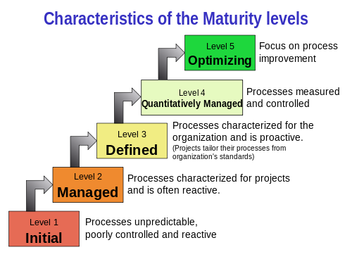

Capability Maturity Model (CCM)

he model provides a theoretical continuum along which process maturity can be developed incrementally from one level to the next. Skipping levels is not allowed/feasible. (Source: Wikipedia)

**Level 1 - Initial**

*(chaotic, ad hoc, individual heroics) - the starting point for use of a new or undocumented repeat process.*

It is characteristic of processes at this level that they are (typically) undocumented and in a state of dynamic change, tending to be driven in an ad hoc, uncontrolled and reactive manner by users or events. This provides a chaotic or unstable environment for the processes. (Example - a surgeon performing a new operation a small number of times - the levels of negative outcome are not known).

It is characteristic of this level of maturity that some processes are repeatable, possibly with consistent results. Process discipline is unlikely to be rigorous, but where it exists it may help to ensure that existing processes are maintained during times of stress.

**Level 3 - Defined**

*The process is defined/confirmed as a standard business process*

It is characteristic of processes at this level that there are sets of defined and documented standard processes established and subject to some degree of improvement over time. These standard processes are in place. The processes may not have been systematically or repeatedly used - sufficient for the users to become competent or the process to be validated in a range of situations. This could be considered a developmental stage - with use in a wider range of conditions and user competence development the process can develop to next level of maturity.

**Level 4 - Managed (Capable)**

*The process is quantitatively managed in accordance with agreed-upon metrics.*

It is characteristic of processes at this level that, using process metrics, effective achievement of the process objectives can be evidenced across a range of operational conditions. The suitability of the process in multiple environments has been tested and the process refined and adapted. Process users have experienced the process in multiple and varied conditions, and are able to demonstrate competence. The process maturity enables adaptions to particular projects without measurable losses of quality or deviations from specifications. Process Capability is established from this level.

**Level 5 - Optimizing (Efficient)**

*Process management includes deliberate process optimization/improvement.*

It is a characteristic of processes at this level that the focus is on continually improving process performance through both incremental and innovative technological changes/improvements. At maturity level 5, processes are concerned with addressing statistical common causes of process variation and changing the process (for example, to shift the mean of the process performance) to improve process performance. This would be done at the same time as maintaining the likelihood of achieving the established quantitative process-improvement objectives.